# Case Study - Inflation and Unemployment

### 09/06/2017

```python
from IPython.display import HTML
HTML('''<script>
code_show=true;
function code_toggle() {
 if (code_show){
 $('div.input').hide();
 } else {
 $('div.input').show();
 }
 code_show = !code_show
}
$( document ).ready(code_toggle);
</script>
To toggle on/off the raw code, click <a href="javascript:code_toggle()">here</a>.''')
```

To toggle on/off the raw code, click here.

- Introduction
- Data Processing
  - Load Packages and Data
  - Exploratory Analysis
- Examination of Phillips' Curve
  - Plotting CPI vs Unemployment Rate
  - Natural Rate of Unemployment
  - Plot CPI vs NROU
  - Plot Features vs Date
  - Economic Performance: SP-500
- Conclusion

# Introduction

Phillips' Curve is an empirical model proposed by the economist William Phillips in 1958. The model describes the historical inverse relationship between the unemployment rate and inflation, based on the data from 1861-1957 in United Kingdom. The Phillips Curve has been contested over years from multiple economic cycles in the US where the inverse relationship between the unemployment rate and inflation failed to hold.

[figure not shown]

In this case study, the inflation and unemployment data from Federal Reserve is analyzed to examine the validity of the Phillips Curve in the US. The data include the monthly records of Consumer Price Index (CPI), Unemployment Level, and Civilian Labor Force covering the time frame from 1948 to 2017. CPI reflects the level of inflation, and the Unemployment Level and Civilian Labor Force result in the Unemployment Rate. Data are analyzed with Python on Jupyter Notebook, and interactive plots are generated to visualize the relationship between inflation and unemployment.

As suggested by economic scholars, the data analysis found that the Phillips' inverse relationship between unemployment and inflation only stands for short period of time, but has not been observed in the long run. Modern Phillips curve models include both a short-run Phillips Curve and a long-run Phillips Curve: While the "short-run Phillips Curve" holds true for the inversed relationship, in the long run the Phillips Curve shifts up through a period of time with both high inflation and high unemployment. Overall, inflation does not seem to affect unemployment in the long run. To further explore the relationship between inflation and unemployment, two additional data sources are analyzed: [Natural Rate of Unemployment (NROU)](https://fred.stlouisfed.org/series/NROU) reveals the Unemployment Rate in the long run; The historical [Standard & Poor's 500 Index](https://finance.yahoo.com/quote/%5EGSPC/history/) (SP500) indicating the US economic performance also strongly affects the Unemployment Rate.

# Data Processing

## Load Packages and Data

This notebook uses several standard Python packages and special packages for plotting. The primary libraries that we'll be using are:

- **pandas**: and **numpy**: numeric paneled data operation.
- **datetime**: processing datetime data.
- **matplotlib** and **seaborn**: data visualization.
- **plotly**: interactive data visualization

```python
import pandas as pd
import numpy as np
import datetime as dt
import matplotlib.pyplot as plt
import seaborn as sns
import plotly as py
import plotly.graph_objs as go

%matplotlib inline
```

```python
df = pd.read_csv('FI Case Data.csv')
```

## Exploratory Analysis

The raw data are imported into Pandas DataFrame from the .csv file. From the raw data, there are four different values in the "Data" column: "Consumer Price Index", "Unemployment Level", "Civilian Labor Force", and "CPI". From analyzing the data it is found that "CPI" is the same as "Consumer Price Index", but just a different name after 2010s. "CPI" is uniformed as "Consumer Price Index".

Next, the DataFrame is reworked by creating three new columns named "Consumer Price Index", "Unemployment Level", and "Civilian Labor Force" with their respective values, indexed by the years and months.

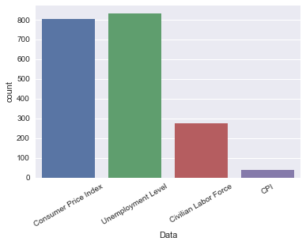

```python
sns.countplot(x = df.Data, data=df)
plt.xticks(rotation = 30)
```

```python
df.Data.replace('CPI', 'Consumer Price Index', inplace=True) # The CPI and 'Consumer Price Index are the same.
```

```python
df = df[df['Year']!= 1947]  # Year 1947 has only Consumer Price Index Data no Unemployment Level. Drop from data.
```

```python
df.rename(columns={'Month ': 'Month'}, inplace=True) # Original "Month" has a space.
```

```python
df_CPI = df[df.Data == 'Consumer Price Index']
df_UL = df[df.Data == 'Unemployment Level']
df_CLF = df[df.Data == 'Civilian Labor Force']
```

```python
df_CPI.index = range(df_CPI.shape[0])
df_UL.index = range(df_UL.shape[0])
df_CLF.index = range(df_CLF.shape[0])
```

```python
df_CPI = df_CPI.rename(columns={'Value': 'Consumer Price Index'})
df_UL = df_UL.rename(columns={'Value': 'Unemployment Level'})
df_CLF = df_CLF.rename(columns={'Value': 'Civilian Labor Force'})
```

```python
df_CPI = df_CPI.drop('Data', axis = 1)
df_UL = df_UL.drop('Data', axis = 1)
df_CLF = df_CLF.drop('Data', axis = 1)
```

In the column of "Civilian Labor Force", there are many null values because this data is only sampled quarterly. Here the null values are imputed by evenly filling the gap between two consecutive data points.

The Unemployment Rate is then calculated by dividing the Civlian Labor Force from the Unemployment Level:

Unemployment Rate = Unemployment Level / Civilian Labor Force

```python
df_new = pd.concat([df_CPI, df_UL.drop(['Year', 'Month'], axis = 1)], axis = 1)
df_new = df_new.merge(df_CLF, how='outer')
```

```python
idx = df_new['Civilian Labor Force'].dropna().index
CLF = df_new['Civilian Labor Force'].values
```

```python
for i in idx:
    CLF[i+1] = np.linspace(CLF[i], CLF[i+3], 4)[1]
    CLF[i+2] = np.linspace(CLF[i], CLF[i+3], 4)[2]
    if i == 825:
        CLF[i+1] = 2 * CLF[i] - CLF[i-1]
        CLF[i+2] = 2 * CLF[i+1] - CLF[i]
        CLF[i+3] = 2 * CLF[i+2] - CLF[i+1]
        CLF[i+4] = 2 * CLF[i+3] - CLF[i+2]
```

```python
df_new['Civilian Labor Force'] = np.round(CLF).astype('int')
```

```python
df_new['Unemployment Rate %'] = round(df_new['Unemployment Level'] / df_new['Civilian Labor Force'] * 100, 2)
```

```python
mon_infl_rate = [np.nan]
for i in range(len(df_new.index)-1):
    mon_infl_rate.append(round((df_new['Consumer Price Index'][i+1] -
                         df_new['Consumer Price Index'][i]) / df_new['Consumer Price Index'][i]*100, 2))
```

```python
df_new['mon_infl_rate'] = mon_infl_rate
```

**Year and Month** The features "Year" and "Month" are combined together in a new string-format column "year_mo", and then the "year_mo" column is converted to datetime.date format for better processing.

The reworked dataframe is shown below.

```python
year_mo = [str(df_new['Year'][i]) + '-' + str(df_new['Month'][i]) for i in df_new.index]
```

```python
year_mo_date = [dt.datetime.strptime(year_mo[i], '%Y-%m').date() for i in df_new.index]
```

```python
df_new['year_mo_date'] = year_mo_date
```

```python
df_new['year_mo'] = year_mo
```

```python
df_new.head()
```

|  | Year | Month | Consumer Price Index | Unemployment Level | Civilian Labor Force | Unemployment Rate % | mon_infl_rate | year_mo_date | year_mo |
| --- | --- | --- | --- | --- | --- | --- | --- | --- | --- |
| 0 | 1948 | 1 | 23.68 | 2034.0 | 60230 | 3.38 | NaN | 1948-01-01 | 1948-1 |
| 1 | 1948 | 2 | 23.67 | 2328.0 | 60332 | 3.86 | -0.04 | 1948-02-01 | 1948-2 |
| 2 | 1948 | 3 | 23.50 | 2399.0 | 60433 | 3.97 | -0.72 | 1948-03-01 | 1948-3 |
| 3 | 1948 | 4 | 23.82 | 2386.0 | 60535 | 3.94 | 1.36 | 1948-04-01 | 1948-4 |
| 4 | 1948 | 5 | 24.01 | 2118.0 | 60668 | 3.49 | 0.80 | 1948-05-01 | 1948-5 |

# Examination of Phillips' Curve

```python
py.offline.init_notebook_mode()
```

## Plotting CPI vs Unemployment Rate

[figure not shown]

```python
layout = go.Layout(
    autosize=False,
    width=600,
    height=600,
    title = 'CPI vs. Unemployment Rate',
    yaxis = dict(
        title = 'Consumer Price Index'
    ),
    xaxis = dict(
        title = 'Unemployment Rate (%)'
    )
)

trace1 = go.Scatter(
    x = df_new['Unemployment Rate %'],
    y = df_new['Consumer Price Index'],
    mode = 'markers',
    marker = dict(
        size='4',
        color = df_new['Year'], #set color equal to a variable
        colorscale='Viridis',
        showscale=True
    ),
    name = 'Relation',
    text = df_new['year_mo']
)


fig = go.Figure(data=[trace1], layout=layout)
py.offline.iplot(fig, filename='styled-scatter')
```

[interactive chart not shown]

```python
turn_pnt = []
turn_year_mo = ['1948-1', '1949-10', '1953-5', '1958-7', '1969-5', '1971-8', '1973-8', '1975-5', '1979-7', '1982-12',
               '1989-5', '1992-6', '2000-10', '2003-6', '2007-3', '2009-10', '2017-2']
for i in turn_year_mo:
    turn_pnt.append(df_new.index[df_new['year_mo'] == i][0])
```

```python
period = []
corr = []
length = []
for i in range(len(turn_year_mo)-1):
    period.append(turn_year_mo[i] +'~'+ turn_year_mo[i+1])
    corr.append(np.corrcoef(df_new['Unemployment Rate %'][turn_pnt[i]:turn_pnt[i+1]].values,
                df_new['Consumer Price Index'][turn_pnt[i]:turn_pnt[i+1]].values)[0][1])
    length.append((df_new['Year'][turn_pnt[i+1]] - df_new['Year'][turn_pnt[i]]) * 12 +
                  df_new['Month'][turn_pnt[i+1]] - df_new['Month'][turn_pnt[i]])

df_cycle = pd.DataFrame({'Period': period, 'Correlation': corr, 'Length_Month': length})
```

```python
df_cycle
```

|  | Correlation | Length_Month | Period |
| --- | --- | --- | --- |
| 0 | -0.435030 | 21 | 1948-1~1949-10 |
| 1 | -0.930429 | 43 | 1949-10~1953-5 |
| 2 | 0.446000 | 62 | 1953-5~1958-7 |
| 3 | -0.854626 | 130 | 1958-7~1969-5 |
| 4 | 0.971927 | 27 | 1969-5~1971-8 |
| 5 | -0.957565 | 24 | 1971-8~1973-8 |
| 6 | 0.895012 | 21 | 1973-8~1975-5 |
| 7 | -0.953288 | 50 | 1975-5~1979-7 |
| 8 | 0.902907 | 41 | 1979-7~1982-12 |
| 9 | -0.939617 | 77 | 1982-12~1989-5 |
| 10 | 0.952526 | 37 | 1989-5~1992-6 |
| 11 | -0.971658 | 100 | 1992-6~2000-10 |
| 12 | 0.843226 | 32 | 2000-10~2003-6 |
| 13 | -0.967202 | 45 | 2003-6~2007-3 |
| 14 | 0.454351 | 31 | 2007-3~2009-10 |
| 15 | -0.955659 | 88 | 2009-10~2017-2 |

```python
trace = []

for i in df_cycle.index:
    trace.append(
        go.Scatter(
        x = df_new['Unemployment Rate %'][turn_pnt[i]:turn_pnt[i+1]],
        y = df_new['mon_infl_rate'][turn_pnt[i]:turn_pnt[i+1]],
        mode = 'markers',
        marker = dict(
            size='4',
            color = df_new['Year'][turn_pnt[i]:turn_pnt[i+1]], #set color equal to a variable
            colorscale='Viridis',
            showscale=True
        ),
        name = df_cycle['Period'][i],
        text = df_new['year_mo']
    )
    )



layout = go.Layout(
    autosize=False,
    width=900,
    height=600,

    yaxis = dict(
        title = 'Monthly Inflation Rate'
    ),
    xaxis = dict(
        title = 'Unemployment Rate (%)'
    ),
    legend=dict(x=1.3, y=1.0)
)

data = trace

fig = go.Figure(data=data, layout=layout)
py.offline.iplot(fig, filename='styled-scatter')
```

[interactive chart not shown]

## Natural Rate of Unemployment

The modern Phillips' curve based on the "expectations-augmented" theory states that the inflation is only inversely correlated with unemployment rate in the short run, but in the long run the unemployment rate falls back to the "Natural Rate of Unemployment" (NROU) not affected by inflation. To test this theory, the NROU data from 1949 was obtained from [Federal Reserve Bank](https://fred.stlouisfed.org/series/NROU). The inflation is plotted with the NROU data in comparison with the actual unemployment rate.

Compared to the drastic changes between inflation and the actual unemployment rate, the NROU data is almost stable over the past 60 years. So this proved the modern Phillips' curve theory that in the long run, inflation does not affect the Natural Rate of Unemployment.

```python
df_NRUO = pd.read_csv('NROU.csv')
```

```python
df_NRUO.rename(columns={'DATE': 'year_mo_date'}, inplace = True)
```

```python
df_NRUO['year_mo_date'] = df_NRUO['year_mo_date'].apply(lambda x: dt.datetime.strptime(x, '%Y-%m-%d').date())
```

```python
df_new = df_new.merge(df_NRUO, on= 'year_mo_date', how = 'outer')
```

## Plot CPI vs NROU

```python
trace1 = go.Scatter(
    x = df_new['NROU'],
    y = df_new['Consumer Price Index'],
    mode = 'markers',
    marker = dict(
        color = ('rgb(255, 0, 0)'),
        size = 5,
    ),

    name = 'CPI vs NROU',
    text = df_new['year_mo_date'],

)

trace2 = go.Scatter(
    x = df_new['Unemployment Rate %'],
    y = df_new['Consumer Price Index'],
    mode = 'markers',
    marker = dict(
        size='4',
        color = df_new['Year'], #set color equal to a variable
        colorscale='Viridis',
        showscale=True
    ),
    name = 'CPI vs. Unemployment Rate',
    text = df_new['year_mo_date']
)



layout = go.Layout(
    autosize=False,
    width=600,
    height=600,

    yaxis = dict(
        title = 'Consumer Price Index'
    ),
    xaxis = dict(
        title = 'Unemployment Rate (%)'
    ),
    legend=dict(x=0, y=1.1)
)

data = [trace1, trace2]

fig = go.Figure(data=data, layout=layout)
py.offline.iplot(fig, filename='styled-scatter')
```

[interactive chart not shown]

## Plot Features vs Date

The plot of inflation and unemployment rate vs time again show that there is not a significant relationship between inflation and unemployment in the past 60 years. While the inflation steadily increases by almost 10 folds, the unemployment rate wobbles between 3% and 11% all the time. Zooming to a small period of time does reflect some correlation between the two.

```python
trace1 = go.Scatter(
    x=df_new['year_mo_date'],
    y=df_new['Consumer Price Index'],
    name='Consumer Price Index'
)
trace2 = go.Scatter(
    x=df_new['year_mo_date'],
    y=df_new['Unemployment Rate %'],
    name='Unemployment Rate %',
    yaxis='y2'
)
data = [trace1, trace2]

layout = go.Layout(
    title='CPI and Unemployment Rate',
    yaxis=dict(
        title='Consumer Price Index',

    ),
    yaxis2=dict(
        title='Unemployment Rate (%)',
        titlefont=dict(
            color='rgb(148, 103, 189)'
        ),
        tickfont=dict(
            color='rgb(148, 103, 189)'
        ),
        overlaying='y',
        showgrid = False,
        side='right'
    )
)
fig = go.Figure(data=data, layout=layout)
py.offline.iplot(fig, filename='multiple-axes-double')
```

[interactive chart not shown]

## Economic Performance: SP-500

There are many factors that influence the unemployment rate, among which the economic cycle may be more influential. In this study the unemployment rate is plotted with the economic performance to gain some more insights. The economic performance is indicated by the [Standard & Poor's 500 Index](https://finance.yahoo.com/quote/%5EGSPC/history/) (SP500), data available from Yahoo Finance. After data processing, the SP500 data are plotted with the unemployment rate vs time.

The SP500 is very apparently negatively correlation with the unemployment, whenever there is an ecnomoic downturn, the SP500 plunges and the unemployment rate uprises. This is especially obvious during the last economic crisis of 2007-2008.

```python
df_SP500 = pd.read_csv('SP500.csv')
df_SP500.drop(['Open', 'High', 'Low', 'Close', 'Volume'], axis = 1, inplace = True)
```

```python
df_SP500.rename(columns={'Date': 'year_mo_date', 'Adj Close':'SP500'}, inplace = True)
```

```python
df_SP500['year_mo_date'] = df_SP500['year_mo_date'].apply(lambda x: dt.datetime.strptime(x, '%m/%d/%Y').date())
```

```python
filt = df_SP500['year_mo_date'].apply(lambda x: True if x.day == 1 else False)
```

```python
df_SP500 = df_SP500[filt]
df_SP500 = df_SP500[df_SP500['year_mo_date'] <= dt.date(2017, 2, 1)]
```

```python
df_new = df_new.merge(df_SP500, on= 'year_mo_date', how = 'outer')
```

```python
trace1 = go.Scatter(
    x=df_new['year_mo_date'],
    y=df_new['SP500'],
    name='SP500',
    mode = 'markers',
    marker = dict(
        size = 4
    )
)
trace2 = go.Scatter(
    x=df_new['year_mo_date'],
    y=df_new['Unemployment Rate %'],
    name='Unemployment Rate %',
    yaxis='y2'
)
data = [trace1, trace2]

layout = go.Layout(
    title='SP500 and Unemployment Rate',
    yaxis=dict(
        title='SP500',
        type='log',
        autorange=True
    ),
    yaxis2=dict(
        title='Unemployment Rate (%)',
        titlefont=dict(
            color='rgb(148, 103, 189)'
        ),
        tickfont=dict(
            color='rgb(148, 103, 189)'
        ),
        overlaying='y',
        showgrid = False,
        side='right'
    )
)
fig = go.Figure(data=data, layout=layout)
py.offline.iplot(fig, filename='multiple-axes-double')
```

[interactive chart not shown]

# Conclusion

One can analyze the relationship between inflation and the unemployment to test the Phillips Curve. From the data of Consumer Price Index and Unemployment Rate of the US in the past 60+ years, the inverse relationship between inflation and unemployment as proposed by Phillips only holds true in the short run. In the long run the inflation does not seem to affect the unemployment, while the unemployment stabilizes around the Natural Rate of Unemployment of an economy. However, the unemployment rate is also influenced by the economic performance, reflected by the SP500 index.